# HW6

Thomas Hutchinson - G#01165078

Due Mar 16 at 9AM

```r
library(tidyverse)
library(broom)
library(hrbrthemes)
library(viridis)
```

# Problem 1 – Binge eating mice

Use the binge.csv dataset to assess the difference in food intake level for mice in 4 different genotypes.

```r
binge <- read_csv("binge.csv")

binge %>%
  select(Genotype) %>%
  distinct()
```

| Genotype |
| --- |
| A |
| B |
| C |
| D |

```r
glimpse(binge)
```

```
## Rows: 30
## Columns: 2
## $ Intake   <dbl> 0.8234188, 0.6489130, 0.9524757, 0.7901818, 0.7921531, 0.7698…
## $ Genotype <chr> "A", "A", "A", "A", "A", "A", "A", "A", "B", "B", "B", "B", "…
```

### A. Clearly state your statistical hypotheses and decide on alpha

> Knowing nothing about the habits or genotypes of binge eating mice, I would first look at the data.

```r
# Look at the variance within each group
binge %>%
  group_by(Genotype) %>%
  summarise(Variance = var(Intake))
```

| Genotype | Variance |
| --- | --- |
| A | 0.011121022 |
| B | 0.048453617 |
| C | 0.006115750 |
| D | 0.005754948 |

> The variances make me wonder, but I don’t really know how much difference is too much at this point, so I just mention it and set it aside for now.

```r
# I really, really like this!
binge_sum <- binge %>%
  group_by(Genotype) %>%
  summarise(mean = mean(Intake, na.rm = TRUE),
          n = n(),
          SD = sd(Intake, na.rm = TRUE),
          lower = mean - SD,
          upper = mean + SD)

binge_sum
```

| Genotype | mean | n | SD | lower | upper |
| --- | --- | --- | --- | --- | --- |
| A | 0.7717382 | 8 | 0.10545626 | 0.6662819 | 0.8771944 |
| B | 1.0869792 | 6 | 0.22012182 | 0.8668573 | 1.3071010 |
| C | 1.2152581 | 8 | 0.07820326 | 1.1370549 | 1.2934614 |
| D | 0.9308339 | 8 | 0.07586138 | 0.8549725 | 1.0066953 |

> With four genotype groups, A, B, C, and D, I will just assume that these mice are all the same, except for the difference in one gene/allele. Therefore:

**H<sub>0</sub>**: $\bar{A}$ = $\bar{B}$ = $\bar{C}$ = $\bar{D}$

> After reviewing some descriptive statistics I see that there is difference in the amount of variance within the groups, with var(A) twice that of var(D).

> Next, I’ll check if the distribution is normal within groups:

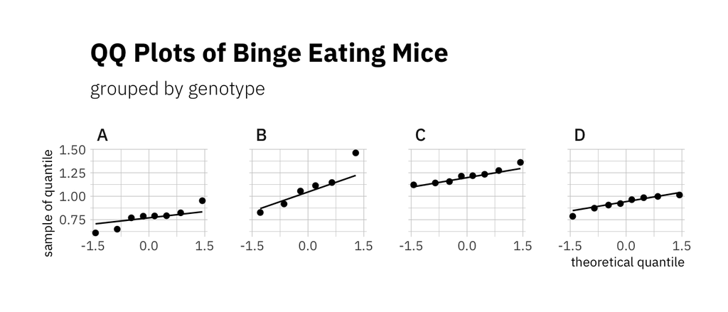

```r
binge %>%
  ggplot(aes(sample=Intake))+
  geom_qq()+
  geom_qq_line() +
  facet_wrap(~Genotype, ncol = 4) +
  theme_ipsum_ps() +
  scale_x_continuous(breaks = c(-1.5, 0, 1.5)) +
  labs(title="QQ Plots of Binge Eating Mice",
       subtitle="grouped by genotype",
       x = "theoretical quantile",
       y = "sample of quantile")
```

> For such a small number of samples, this is much more ‘normal’ than I expected, so I’ll continue, assuming normality has been met.

> It is possible that there may not be a statistical difference between all of the groups, but one or more group may be statistically different to one or more others in the group. I’m not certain of the proper way to describe this, but I would at least state that:

**H<sub>1</sub>**: $\bar{A}$ <> $\bar{B}$ <> $\bar{C}$ <> $\bar{D}$

> I also see that we have a small number of samples from each group. I want the power of my test to be higher, and without being able to increase the sample size, I will set the threshold of rejecting the null hypothesis to be higher, so I arbitrarily set alpha as 0.01.

### B. Run the test and interpret the ANOVA output

```r
# Intake, dependent on Genotype
fit <- lm(Intake ~ Genotype,
          data = binge)

anova(fit)
```

|  | Df | Sum Sq | Mean Sq | F value | Pr(>F) |
| --- | --- | --- | --- | --- | --- |
| Genotype | 3 | 0.8705681 | 0.29018938 | 18.71214 | 1.126434e-06 |
| Residuals | 26 | 0.4032101 | 0.01550808 | NA | NA |

> So there are significant difference between groups…

```r
summary(fit)
```

```
##
## Call:
## lm(formula = Intake ~ Genotype, data = binge)
##
## Residuals:
##      Min       1Q   Median       3Q      Max
## -0.26043 -0.05873  0.00991  0.05318  0.37508
##
## Coefficients:
##             Estimate Std. Error t value Pr(>|t|)
## (Intercept)  0.77174    0.04403  17.528 6.39e-16 ***
## GenotypeB    0.31524    0.06725   4.687 7.67e-05 ***
## GenotypeC    0.44352    0.06227   7.123 1.45e-07 ***
## GenotypeD    0.15910    0.06227   2.555   0.0168 *
## ---
## Signif. codes:  0 '***' 0.001 '**' 0.01 '*' 0.05 '.' 0.1 ' ' 1
##
## Residual standard error: 0.1245 on 26 degrees of freedom
## Multiple R-squared:  0.6835, Adjusted R-squared:  0.6469
## F-statistic: 18.71 on 3 and 26 DF,  p-value: 1.126e-06
```

> The ANOVA table indicates that there is a significant difference in the means of the four groups, with a very low p-value. This indicates that the means of the four groups are different, but does not tell us which one is ‘more different’ or if there are any two groups that are by themselves *not* significantly different. It’s not Thanksgiving yet, but it certainly is time for Tukey.

### C. If it is appropriate, run a Tukey’s HSD post-hoc analysis to determine which group differs. Interpret the output.

```r
tidy(TukeyHSD(aov(fit)))
```

| term | contrast | null.value | estimate | conf.low | conf.high | adj.p.value |
| --- | --- | --- | --- | --- | --- | --- |
| Genotype | B-A | 0 | 0.3152410 | 0.13073991 | 0.49974205 | 4.218379e-04 |
| Genotype | C-A | 0 | 0.4435199 | 0.27270514 | 0.61433474 | 8.386271e-07 |
| Genotype | D-A | 0 | 0.1590957 | -0.01171911 | 0.32991049 | 7.453036e-02 |
| Genotype | C-B | 0 | 0.1282790 | -0.05622211 | 0.31278003 | 2.496366e-01 |
| Genotype | D-B | 0 | -0.1561453 | -0.34064636 | 0.02835578 | 1.189733e-01 |
| Genotype | D-C | 0 | -0.2844243 | -0.45523905 | -0.11360945 | 5.752400e-04 |

> With these results we can see that groups A and C are the groups with the greatest (and statistically significant) difference between their means.

> There was no statistically significant difference in the means of groups B-C (*P*=0.250), and B-D (*P*=0.119).

> There was a marginally significant difference in the means of groups A-D (*P*=0.0745).

> There was a statistically significant difference in the means of groups A-B (*P*<0.001), A-C (*P*<0.0001), and C-D (*P*<0.001).

> With such small sample sizes, though, we have to be aware of the chance that this may not be representative of a larger group/population.

### D. Create a publication-ready visualization to show your results

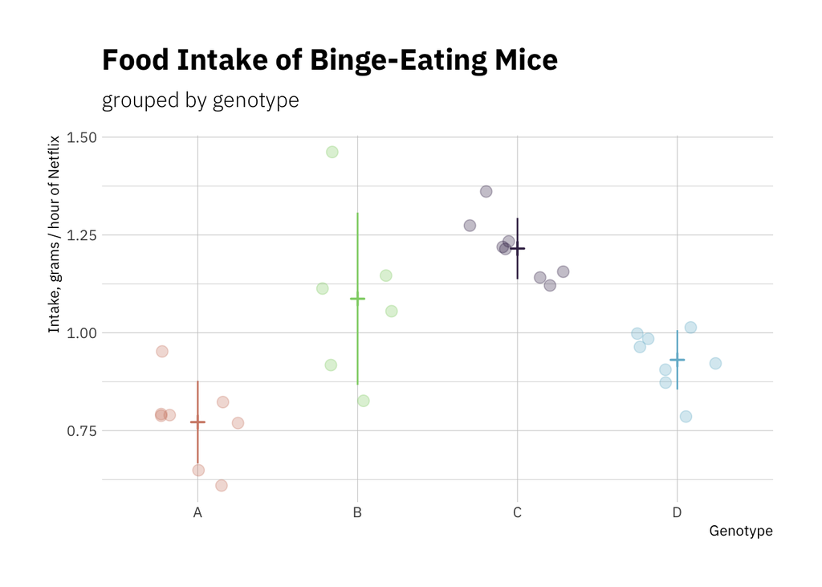

```r
binge %>%
  ggplot( ) +

  # Add data points
  geom_jitter(aes(Genotype, Intake, color = Genotype),
              width = .3, alpha = .3, size = 3) +

  # Add mean and SD range
  geom_pointrange(data = binge_sum,
                  aes(x = Genotype, y = mean,
                      ymin = lower, ymax = upper,
                      color = Genotype),
                  shape = 3) +

  # Set theme, colors, and labels
  theme_ipsum_ps() + scale_color_ipsum() +
  labs(title="Food Intake of Binge-Eating Mice",
       subtitle = "grouped by genotype",
    y = "Intake, grams / hour of Netflix") +


  # No need for a legend
  theme(legend.position="none")
```

# Problem 2 – Movies

You might have heard of the Bechdel’s test where a movie passes if it:

1. has at least two women in it, who
2. talk to each other, about
3. something besides a man

I recently stumbled on a (old) interesting article analyzing whether the number of words spoken by male and female characters in movies was balanced or not. To see their whole analysis, head to [the pudding](https://pudding.cool/2017/03/film-dialogue/index.html).

I cleaned up their dataset (added titles) so that we can use it to run some statistics.

### A. Understand the dataset

Load in the words_movies.csv dataset and use some dplyr functions to print out the top 50 grossing movies. *Note this dataset has movies from 1929 through 2015 so it does not have our most recent blockbuster hits*

```r
movies <- read_csv("words_movies.csv")

movies %>%
  select(title, year, gross) %>%
  distinct() %>%
  arrange(desc(gross)) %>%
  print(n=50)
```

```
## # A tibble: 2,000 x 3
##    title                                              year gross
##    <chr>                                             <dbl> <dbl>
##  1 Star Wars: Episode IV - A New Hope                 1977  1798
##  2 Titanic                                            1997  1249
##  3 Jaws                                               1975  1103
##  4 The Jungle Book                                    1967  1029
##  5 Star Wars: Episode V - The Empire Strikes Back     1980   937
##  6 Star Wars: Episode VII - The Force Awakens         2015   927
##  7 Avatar                                             2009   882
##  8 The Lion King                                      1994   880
##  9 Sleeping Beauty                                    1959   880
## 10 Star Wars: Episode VI - Return of the Jedi         1983   853
## 11 Jurassic Park                                      1993   844
## 12 The Wizard of Oz                                   1939   839
```

[output cut: 39 more lines]

### B. Choose one movie title and create a dataset that filters the whole movies dataset for just your choice.

> I wanted to choose Amelie, the first ‘fun’ one while scrolling down from the top.

```r
movies %>%
  select(title) %>%
  arrange(desc(title)) %>%
  distinct() %>%
  filter(str_detect(title, "^Am"))
```

| title |
| --- |
| Am\xe9lie |
| Amour |
| American Ultra |
| American Splendor |
| American Sniper |
| American Shaolin |
| American Psycho |
| American Pie |
| American Outlaws |
| American Madness |

[output cut: 8 more lines]

> Uh, oh. I know there’s a diacritical mark over the first `e`…

```r
# I didn't realize I was picking a 'hard one' at the time...

amelie <- movies %>%
  filter(str_detect(title, "^Am"),
         gross == 51) %>%
  mutate(title = "Amelie",
         imdb_character_name = case_when(age == 25 ~ "Amelie Poulain",
                                         TRUE ~ imdb_character_name))

amelie
```

| title | year | gross | imdb_character_name | gender | age | words |
| --- | --- | --- | --- | --- | --- | --- |
| Amelie | 2001 | 51 | Amelie Poulain | f | 25 | 1908 |
| Amelie | 2001 | 51 | collignon | m | NULL | 412 |
| Amelie | 2001 | 51 | dominique breto | m | 58 | 147 |
| Amelie | 2001 | 51 | eva | f | 35 | 343 |
| Amelie | 2001 | 51 | georgette | f | 39 | 376 |
| Amelie | 2001 | 51 | gina | f | NULL | 350 |
| Amelie | 2001 | 51 | hipolito | m | 44 | 263 |
| Amelie | 2001 | 51 | husband | m | NULL | 233 |
| Amelie | 2001 | 51 | joseph | m | 46 | 360 |
| Amelie | 2001 | 51 | lucien | m | 26 | 337 |

[output cut: 4 more lines]

### C. Let’s say we are interested in whether the sum of words spoken by male characters equals that of female characters. State your statistical hypotheses and alpha.

> Note that the sum implies that we will analyze count data. A t-test is not appropriate for count data.

> With the assumption of not having any special knowledge, we would state:

> **H<sub>0</sub>**: words spoken by masculine character = words spoken by feminine character

> To analyze this, we would be comparing the proportion of words spoken by gender. In the case of this particular movie, I have prior knowledge of this film and know that the title character is a feminine character, so based on this I would expect there to be more words spoken by feminine characters than masculine characters.

> **H<sub>1</sub>**: words spoken by masculine character < words spoken by feminine character

> I have no reason *not* to set alpha at 0.05, but it is arbitrary.

### D. For your movie dataset, sum up the number of words spoken by males and by females.

```r
words <- amelie %>%
  group_by(gender) %>%
  summarise(word_count = sum(words))

words
```

| gender | word_count |
| --- | --- |
| f | 3887 |
| m | 3093 |

### E. What type of test is this? How do you know?

> This is discrete data, a count of words in which each word is categorized as being spoken by a feminine or masculine character. This is a comparison of proportions between two groups.

> In this case, we actually *know* the `P`, or the whole population of words in this movie.

> Since this is a binomial choice between a feminine or masculine character, there really aren’t two categories to compare (unless there was a non-binary gender character recorded in the dataset). The words spoken by masculine characters are equal to the total number of words minus the words spoken by feminine characters. Therefore, this should be analyzed with a one-proportion z-test.

### F. Check the assumptions of this test.

> The number of words spoken is not a sample of the entire population, but rather *is* the entire population, so there is no need to analyze whether the samples were taken randomly or to assess the number of samples. The total number of words is 6980, so this is not a small population.

### G. Run the test and interpret the output

```r
total_words <- sum(words$word_count)

fem_words <- words %>% filter(gender == "f")
fem_words <- fem_words$word_count

prop.test(x = fem_words,
          n = total_words,
          p = 0.5,
          alternative = "greater")
```

```
##
##  1-sample proportions test with continuity correction
##
## data:  fem_words out of total_words, null probability 0.5
## X-squared = 90.093, df = 1, p-value < 2.2e-16
## alternative hypothesis: true p is greater than 0.5
## 95 percent confidence interval:
##  0.5470048 1.0000000
## sample estimates:
##         p
## 0.5568768
```

> In this movie, the number of words spoken by a feminine character (n=3887) was greater than those spoken by a masculine character (n=3093) and the difference was statistically significant (*P*=<0.0001).

# Problem 3 – Movie genre

genre_movies.csv is a pared down dataset of the movies dataset we used above.

Use the genre_movies dataset to assess the association between words spoken by each gender within each genre of movie. Follow all steps of hypothesis testing to run a contingency table test (test of independence) for these data.

### A. Write out your statistical hypotheses and alpha

> Armed with some background in watching movies and admitting to peeking at the data for way too long instead of working on the actual homework, I was surprised to see that the movie I picked was somewhat of an exception. Still, trying to remember my previous less-biased state, I would have suggested the following hypotheses:

> **H<sub>0</sub>**: words spoken by masculine character = words spoken by feminine character across all genres.

> **H<sub>1</sub>**: words spoken by masculine character > words spoken by feminine character in the genre “Action.”

> **H<sub>2</sub>**: words spoken by masculine character < words spoken by feminine character in the genre “Romance.”

> This is not some sterotypical view, but just what I glean from what I hear when I’m busy on homework all weekend and my wife takes the opportunity to be a Genotype C house mouse and binges Netflix for a few hours on a Sunday afternoon.

### B. Read in the data. Then use `xtabs(words ~ gender + genre, data = genres)` to create a cross tabulation words spoken by each gender in each genre.

```r
genres <- read_csv("genre_movies.csv")

genre_tab <- xtabs(words ~ gender + genre, data = genres)

genre_tab
```

```
##       genre
## gender Action Adventure Animation Biography Comedy  Crime  Drama Fantasy Horror
##      f 205690     63418     35930     68799 217413  56017 235987     284  34546
##      m 750935    192170    128357    260945 368356 262484 398922    3039  42775
##       genre
## gender Mystery Romance Thriller
##      f   13975    3222     2833
##      m   32776   12258     6392
```

### C. Check assumptions:

> The assumptions include random sampling.

```r
movies_by_genre <- genres %>%
  group_by(genre)%>%
  summarise(num_total_by_genre = n()) %>%
  arrange(desc(num_total_by_genre)) %>%
  print(n=Inf)
```

```
## # A tibble: 12 x 2
##    genre     num_total_by_genre
##    <chr>                  <int>
##  1 Action                  1146
##  2 Drama                    702
##  3 Comedy                   549
##  4 Biography                435
##  5 Crime                    352
##  6 Adventure                320
##  7 Animation                200
##  8 Horror                   103
##  9 Mystery                   40
## 10 Romance                   12
## 11 Thriller                  11
## 12 Fantasy                    4
```

> By looking at the number of movies in each genre group, we find that they range from 1146 Action movies to only 4 Fantasy movies. I don’t need special knowledge about the *exact* distribution of movie genres to believe that this is not a random sample. I could be wrong, though.

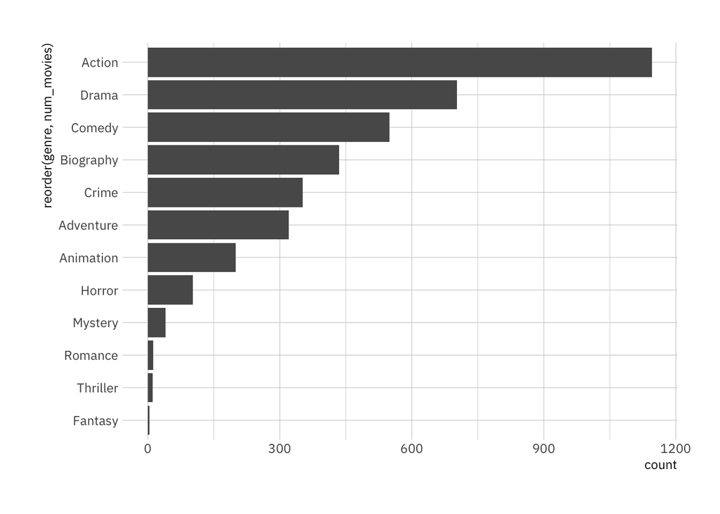

```r
genres %>%
  group_by(genre)%>%
  mutate(num_movies = n()) %>%
  ggplot(aes(y = reorder(genre, num_movies) ) ) +
  geom_bar(stat = "count") +
  theme_ipsum_ps()
```

```r
summary(genres$year)
```

```
##    Min. 1st Qu.  Median    Mean 3rd Qu.    Max.
##    1959    2008    2011    2010    2013    2015
```

> I’m going to go out on a limb and say that between 1959 and 2015 there were more than 4 Fantasy films released. This doesn’t look like random sampling.

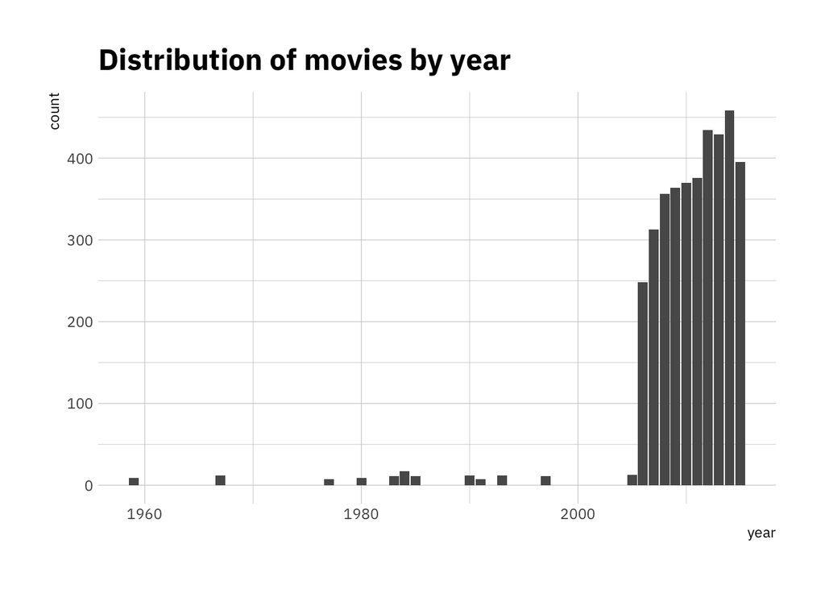

```r
genres %>%
  group_by(year) %>%
  ggplot(aes(x = year) ) +
  geom_bar(stat = "count") +

  # Set theme, colors, and labels
  theme_ipsum_ps() + scale_color_ipsum() +
  labs(title="Distribution of movies by year")
```

> Looking at just the years from 2006 forward that have more than 200 titles, last Friday (before I realized how little time I really *should* have been spending look at this), I made a heatmap to look at distribution across two scales, just to see how it worked in R. I know it doesn’t need to be here, but why delete it?!

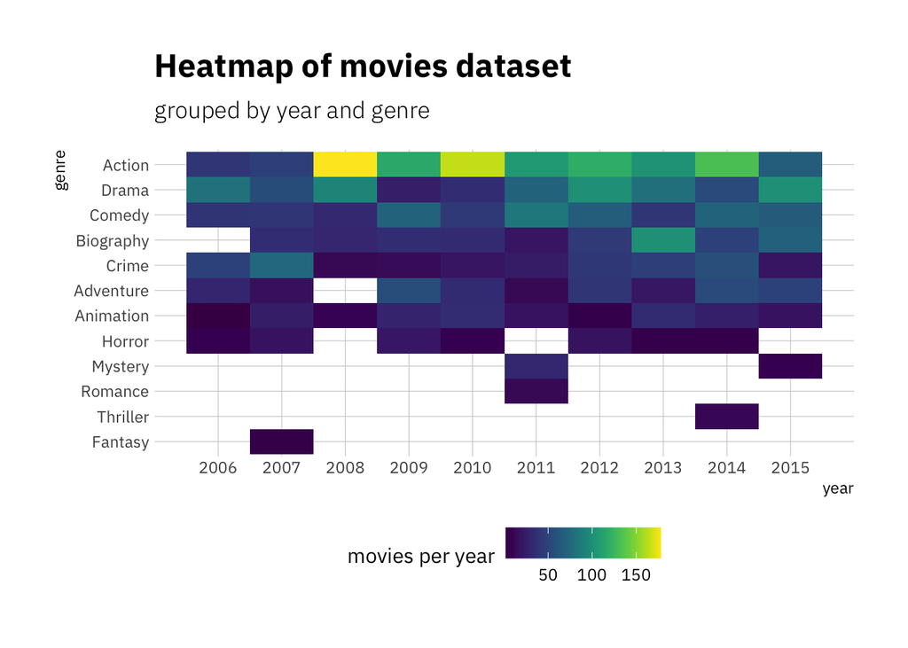

```r
genres %>%
  filter(year > 2005) %>%
  group_by(year, genre) %>%
  summarise(movies_per_year = n() ) %>%

  # Add the sort order of most number of movies per genre
  inner_join(y = movies_by_genre) %>%

  ggplot(aes(y = reorder(genre, num_total_by_genre),
             x = year,
             fill = movies_per_year) ) +
  geom_tile() +

  # Set color palette, titles, and axis labels
  scale_fill_viridis(name = "movies per year") +
  scale_x_continuous(breaks = seq(2006,2015,1)) +
  theme_ipsum_ps(grid = "XY",) +
  labs(title = "Heatmap of movies dataset",
       subtitle = "grouped by year and genre",
       x = "year", y = "genre") +
  theme(legend.position="bottom")
```

### D. Run the test

```r
# Transpose, just because I think it's easier to read that way
# genre_tab <- t(genre_tab)

# Observed
genre_tab
```

```
##       genre
## gender Action Adventure Animation Biography Comedy  Crime  Drama Fantasy Horror
##      f 205690     63418     35930     68799 217413  56017 235987     284  34546
##      m 750935    192170    128357    260945 368356 262484 398922    3039  42775
##       genre
## gender Mystery Romance Thriller
##      f   13975    3222     2833
##      m   32776   12258     6392
```

```r
# Expected
chisq.test(genre_tab)$expected
```

```
##       genre
## gender   Action Adventure Animation Biography   Comedy     Crime    Drama
##      f 264140.5   70572.2  45362.44  91047.94 161740.8  87943.55 175309.2
##      m 692484.5  185015.8 118924.56 238696.06 424028.2 230557.45 459599.8
##       genre
## gender   Fantasy   Horror  Mystery   Romance Thriller
##      f  917.5369 21349.65 12908.75  4274.292  2547.18
##      m 2405.4631 55971.35 33842.25 11205.708  6677.82
```

```r
# Results
chi <- chisq.test(genre_tab)
chi
```

```
##
##  Pearson's Chi-squared test
##
## data:  genre_tab
## X-squared = 112982, df = 11, p-value < 2.2e-16
```

### E. Interpret the results. Which genres have more female words than expected by chance?

> There is a statistically significant difference (*P*<0.001) in words spoken my feminine and masculine roles in the non-randomly sampled movies (n=1994) that are in this dataset.

> I’m such a sleep-deprived dumbass. I’ve been beating my head against the keyboard trying a bunch of different things, and I think it was just a really easy answer:

```r
chi$residuals
```

```
##       genre
## gender      Action   Adventure   Animation   Biography      Comedy       Crime
##      f -113.728812  -26.930498  -44.286960  -73.735092  138.429471 -107.658925
##      m   70.239746   16.632473   27.351950   45.539332  -85.495054   66.490939
##       genre
## gender       Drama     Fantasy      Horror     Mystery     Romance    Thriller
##      f  144.919730  -20.915110   90.314738    9.384646  -16.095486    5.663218
##      m  -89.503485   12.917325  -55.779043   -5.796026    9.940690   -3.497645
```